### CS6375: Machine Learning (Spring '19)

**Instructor**: Gautam Kunapuli  
**Due**: In class, **February 27 (Wednesday)**

# *Homework 2*

The report component of this assignment is the **hard copy** of this homework, along with your answers to questions, and is **due at the start of class on Wednesday, February 27, 2019**.

The **electronic version** of this homework **must be uploaded on eLearning by 12:59pm Central Standard Time, Wednesday, February 27, 2019**. All deadlines are hard and without exceptions unless permission was obtained from the instructor **in advance**.

You may work in groups to discuss the problems and work through solutions together. However, you must **write up your solutions on your own**, without copying another student's work or letting another student copy your work. In your solution for each problem, you must write down the names of your partner (if any); this will not affect your grade.

# 1. **Support Vector Machines with Synthetic Data**, 50 points.

For this problem, we will generate synthetic data for a nonlinear binary classification problem and partition it into training, validation and test sets. Our goal is to understand the behavior of SVMs with Radial-Basis Function (RBF) kernels with different values of $C$ and $\gamma$.

```python
#
# DO NOT EDIT THIS FUNCTION; IF YOU WANT TO PLAY AROUND WITH DATA GENERATION,
# MAKE A COPY OF THIS FUNCTION AND THEN EDIT
#
import numpy as np
from sklearn.datasets import make_moons
from sklearn.model_selection import train_test_split
from sklearn.metrics import accuracy_score
import matplotlib.pyplot as plt
from matplotlib.colors import ListedColormap
from sklearn.svm import SVC
from sklearn.metrics import hinge_loss
import pprint

def generate_data(n_samples, tst_frac=0.2, val_frac=0.2):
  # Generate a non-linear data set
  X, y = make_moons(n_samples=n_samples, noise=0.25, random_state=42)

  # Take a small subset of the data and make it VERY noisy; that is, generate outliers
  m = 30
  np.random.seed(42)
  ind = np.random.permutation(n_samples)[:m]
  X[ind, :] += np.random.multivariate_normal([0, 0], np.eye(2), (m, ))
  y[ind] = 1 - y[ind]

  # Plot this data
  cmap = ListedColormap(['#b30065', '#178000'])
  plt.scatter(X[:, 0], X[:, 1], c=y, cmap=cmap, edgecolors='k')

  # First, we use train_test_split to partition (X, y) into training and test sets
  X_trn, X_tst, y_trn, y_tst = train_test_split(X, y, test_size=tst_frac,
                                                random_state=42)

  # Next, we use train_test_split to further partition (X_trn, y_trn) into training and validation sets
  X_trn, X_val, y_trn, y_val = train_test_split(X_trn, y_trn, test_size=val_frac,
                                                random_state=42)

  return (X_trn, y_trn), (X_val, y_val), (X_tst, y_tst)
```

```python
#
#  DO NOT EDIT THIS FUNCTION; IF YOU WANT TO PLAY AROUND WITH VISUALIZATION,
#  MAKE A COPY OF THIS FUNCTION AND THEN EDIT
#

def visualize(models, param, X, y):
  # Initialize plotting
  if len(models) % 3 == 0:
    nrows = len(models) // 3
  else:
    nrows = len(models) // 3 + 1

  fig, axes = plt.subplots(nrows=nrows, ncols=3, figsize=(15, 5.0 * nrows))
  cmap = ListedColormap(['#b30065', '#178000'])

  # Create a mesh
  xMin, xMax = X[:, 0].min() - 1, X[:, 0].max() + 1
  yMin, yMax = X[:, 1].min() - 1, X[:, 1].max() + 1
  xMesh, yMesh = np.meshgrid(np.arange(xMin, xMax, 0.01),
                             np.arange(yMin, yMax, 0.01))

  for i, (p, clf) in enumerate(models.items()):
    # if i > 0:
    #   break
    r, c = np.divmod(i, 3)
    ax = axes[r, c]

    # Plot contours
    zMesh = clf.decision_function(np.c_[xMesh.ravel(), yMesh.ravel()])
    zMesh = zMesh.reshape(xMesh.shape)
    ax.contourf(xMesh, yMesh, zMesh, cmap=plt.cm.PiYG, alpha=0.6)

    if (param == 'C' and p > 0.0) or (param == 'gamma'):
      ax.contour(xMesh, yMesh, zMesh, colors='k', levels=[-1, 0, 1],
                 alpha=0.5, linestyles=['--', '-', '--'])

    # Plot data
    ax.scatter(X[:, 0], X[:, 1], c=y, cmap=cmap, edgecolors='k')
    ax.set_title('{0} = {1}'.format(param, p))
```

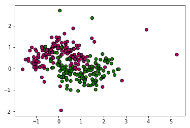

```python
# Generate the data
n_samples = 300    # Total size of data set
(X_trn, y_trn), (X_val, y_val), (X_tst, y_tst) = generate_data(n_samples)
```

### **a**. (25 points) The effect of the regularization parameter, $C$

Complete the Python code snippet below that takes the generated synthetic 2-d data as input and learns non-linear SVMs. Use scikit-learn's [SVC](https://scikit-learn.org/stable/modules/generated/sklearn.svm.SVC.html) function to learn SVM models with **radial-basis kernels** for fixed $\gamma$ and various choices of $C \in \{10^{-3}, 10^{-2}\, \cdots, 1, \, \cdots\, 10^5\}$. The value of $\gamma$ is fixed to $\gamma = \frac{1}{d \cdot \sigma_X}$, where $d$ is the data dimension and $\sigma_X$ is the standard deviation of the data set $X$. SVC can automatically use these setting for $\gamma$ if you pass the argument gamma = 'scale' (see documentation for more details).

**Plot**: For each classifier, compute **both** the **training error** and the **validation error**. Plot them together, making sure to label the axes and each curve clearly.

**Discussion**: How do the training error and the validation error change with $C$? Based on the visualization of the models and their resulting classifiers, how does changing $C$ change the models? Explain in terms of minimizing the SVM's objective function $\frac{1}{2} \mathbf{w}^\prime \mathbf{w} \, + \, C \, \Sigma_{i=1}^n \, \ell(\mathbf{w} \mid \mathbf{x}_i, y_i)$, where $\ell$ is the hinge loss for each training example $(\mathbf{x}_i, y_i)$.

**Final Model Selection**: Use the validation set to select the best the classifier corresponding to the best value, $C_{best}$. Report the accuracy on the **test set** for this selected best SVM model. *Note: You should report a single number, your final test set accuracy on the model corresponding to $C*{best}$_.

```
The best value of C is 1.0
The accuracy of the model for the best value of C is:  0.65
```

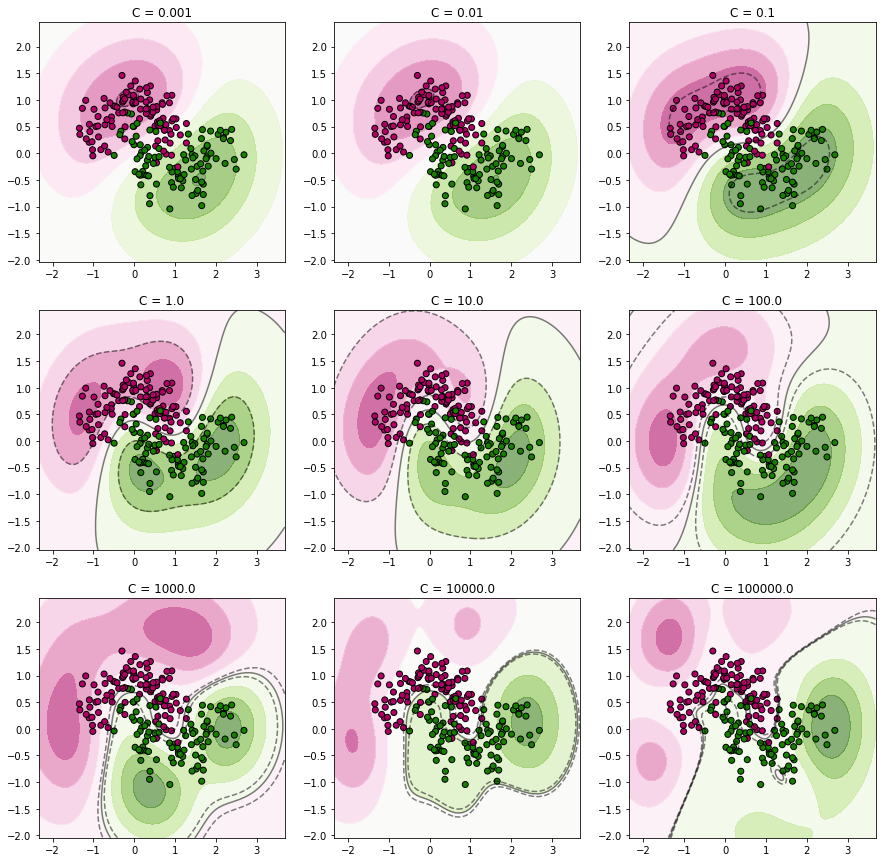

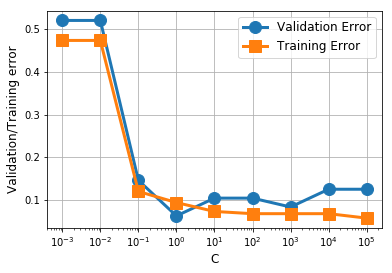

```python
# Learn support vector classifiers with a radial-basis function kernel with
# fixed gamma = 1 / (n_features * X.std()) and different values of C
C_range = np.arange(-3.0, 6.0, 1.0)
C_values = np.power(10.0, C_range)

models = dict()
trnErr = dict()
valErr = dict()
tstErr = dict()

for C in C_values:
    models[C]=SVC(C=C, cache_size=200, class_weight=None, coef0=0.0,
                  decision_function_shape='ovr', degree=3, gamma='scale', kernel='rbf',
                  max_iter=-1, probability=False, random_state=None, shrinking=True,
                  tol=0.001, verbose=False)
    fit = models[C].fit(X_trn, y_trn)

    #trnErr[C] = hinge_loss(y_trn, models[C].decision_function(X_trn))
    #valErr[C] = hinge_loss(y_val, models[C].decision_function(X_val))
    trnErr[C] = 1 - fit.score(X_trn, y_trn)
    valErr[C] = 1 - fit.score(X_val, y_val)
    #tstErr[C] = 1 - fit.score(X_tst, y_tst)

visualize(models, 'C', X_trn, y_trn)

C_bst = min(valErr, key=valErr.get)
print("The best value of C is",C_bst)
y_pred = models[C_bst].predict(X_tst)
accuracy = accuracy_score(y_tst, y_pred)
print("The accuracy of the model for the best value of C is: ",accuracy)


plt.figure()
plt.grid()
plt.xscale('log')
plt.plot(valErr.keys(), valErr.values(), marker='o', linewidth=3, markersize=12)
plt.plot(trnErr.keys(), trnErr.values(), marker='s', linewidth=3, markersize=12)
plt.xlabel('C', fontsize=12)
plt.ylabel('Validation/Training error', fontsize=12)
plt.xticks(list(valErr.keys()), fontsize=10)
plt.legend(['Validation Error', 'Training Error'], fontsize=12)
```

If C is small, the influence of loss is small. The margin is larger and the model is simpler. Bias is high. The model underfits the data points. We have a simpler decision function, at the cost of training accuracy.

As C increases, the model tries to fit almost every data point and thus fits noise. A smaller margin will be accepted if the decision function is better at classifying all training points correctly at higher C. Thus, it becomes highly complex. Thus bias is less and variance is high. It overfits.

Thus, C behaves as a regularization parameter in the SVM.

From the visualization of the model, at lower values of C, i.e. 0.001,0.01, the model is very simple. Bias is high. It underfits. At higher values of C like 1000, 10000, 100000, the model becomes highly complex. Variance is high. It overfits. At C=1, there's a trade-off between bias and variance. So the best value of C is 1 where the validation error is minimum.

SVM's objective function: 1/2(𝐰′𝐰)+𝐶 Σℓ(𝐰∣𝐱𝑖,𝑦𝑖)  
i is from 1 to n; 𝐱𝑖 sre the training examples;𝑦𝑖 are the training labels.

𝐰′𝐰 is the regularization term. Regularization is a technique to avoid overfitting. 𝐶 Σℓ(𝐰∣𝐱𝑖,𝑦𝑖) is the hinge loss term. In soft margin SVM, it penalizes misclassifications. In hard margin SVM there are, by definition, no misclassifications.

### **b**. (25 points) The effect of the RBF kernel parameter, $\gamma$

Complete the Python code snippet below that takes the generated synthetic 2-d data as input and learns various non-linear SVMs. Use scikit-learn's [SVC](https://scikit-learn.org/stable/modules/generated/sklearn.svm.SVC.html) function to learn SVM models with **radial-basis kernels** for fixed $C$ and various choices of $\gamma \in \{10^{-2}, 10^{-1}\, 1, 10, \, 10^2 \, 10^3\}$. The value of $C$ is fixed to $C = 10$.

**Plot**: For each classifier, compute **both** the **training error** and the **validation error**. Plot them together, making sure to label the axes and each curve clearly.

**Discussion**: How do the training error and the validation error change with $\gamma$? Based on the visualization of the models and their resulting classifiers, how does changing $\gamma$ change the models? Explain in terms of the functional form of the RBF kernel, $\kappa(\mathbf{x}, \,\mathbf{z}) \, = \, \exp(-\gamma \cdot \|\mathbf{x} - \mathbf{z} \|^2)$

**Final Model Selection**: Use the validation set to select the best the classifier corresponding to the best value, $\gamma_{best}$. Report the accuracy on the **test set** for this selected best SVM model. *Note: You should report a single number, your final test set accuracy on the model corresponding to $\gamma*{best}$_.

```
The best value of G is 1.0
The accuracy of the model for the best value of G is:  0.6666666666666666
```

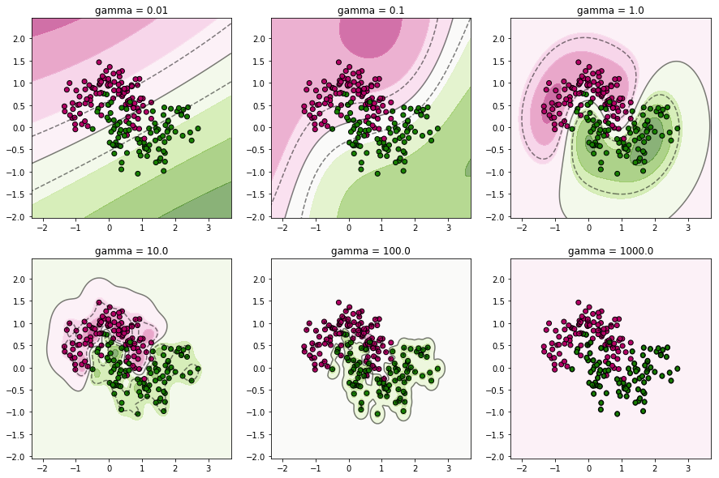

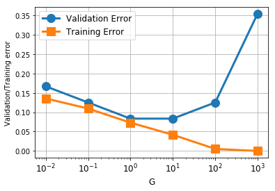

```python
# Learn support vector classifiers with a radial-basis function kernel with
# fixed C = 10.0 and different values of gamma
gamma_range = np.arange(-2.0, 4.0, 1.0)
gamma_values = np.power(10.0, gamma_range)

models = dict()
trnErr = dict()
valErr = dict()
tstErr = dict()

for G in gamma_values:
    models[G]=SVC(C=10, cache_size=200, class_weight=None, coef0=0.0,
                  decision_function_shape='ovr', degree=3, gamma=G, kernel='rbf',
                  max_iter=-1, probability=False, random_state=None, shrinking=True,
                  tol=0.001, verbose=False)
    fit = models[G].fit(X_trn, y_trn)

    #trnErr[G] = hinge_loss(y_trn, models[G].decision_function(X_trn))
    #valErr[G] = hinge_loss(y_val, models[G].decision_function(X_val))
    trnErr[G] = 1 - fit.score(X_trn, y_trn)
    valErr[G] = 1 - fit.score(X_val, y_val)
    #tstErr[G] = 1 - fit.score(X_tst, y_tst)

visualize(models, 'gamma', X_trn, y_trn)

bst_val = min(valErr, key=valErr.get)
print("The best value of G is",bst_val)
y_pred = models[bst_val].predict(X_tst)
accuracy = accuracy_score(y_tst, y_pred)
print("The accuracy of the model for the best value of G is: ",accuracy)


plt.figure()
plt.grid()
plt.xscale('log')
plt.plot(valErr.keys(), valErr.values(), marker='o', linewidth=3, markersize=12)
plt.plot(trnErr.keys(), trnErr.values(), marker='s', linewidth=3, markersize=12)
plt.xlabel('G', fontsize=12)
plt.ylabel('Validation/Training error', fontsize=10)
plt.xticks(list(valErr.keys()), fontsize=12)
plt.legend(['Validation Error', 'Training Error'], fontsize=12)
```

If 𝛾 is small, the influence of loss is small. The model is simple and thus has high bias. The model underfits the data points. As 𝛾 increases, the model tries to fit almost every data point. Thus, it becomes highly complex. The bias is less and variance is high. It is highly sensitive to noise. It starts overfitting.

RBF kernel: 𝜅(𝐱,𝐳)=exp(−𝛾⋅‖𝐱−𝐳‖2) ‖𝐱−𝐳‖2 is the squared Euclidean distance between the two feature vectors. 𝛾 is the regularization factor.

At 𝛾 = 1, there's a trade-off between bias and variance. So the best value of 𝛾 is selected to be 1.

# 2. **Breast Cancer Diagnosis with Support Vector Machines**, 25 points.

For this problem, we will use the Wisconsin Breast Cancer) data set, which has already been pre-processed and partitioned into training, validation and test sets. Numpy's [loadtxt](https://docs.scipy.org/doc/numpy-1.13.0/reference/generated/numpy.loadtxt.html) command can be used to load CSV files.

```python
# Load the Breast Cancer Diagnosis data set; download the files from eLearning
# CSV files can be read easily using np.loadtxt()
wdbc_trn = np.loadtxt('wdbc_trn.csv', delimiter = ',')
wdbc_tst = np.loadtxt('wdbc_tst.csv', delimiter = ',')
wdbc_val = np.loadtxt('wdbc_val.csv', delimiter = ',')

X_trn = np.array(wdbc_trn[:,1:])
y_trn = np.array(wdbc_trn[:,0])

X_tst = np.array(wdbc_tst[:,1:])
y_tst = np.array(wdbc_tst[:,0])

X_val = np.array(wdbc_val[:,1:])
y_val = np.array(wdbc_val[:,0])
```

Use scikit-learn's [SVC](https://scikit-learn.org/stable/modules/generated/sklearn.svm.SVC.html) function to learn SVM models with **radial-basis kernels** for **each combination** of $C \in \{10^{-2}, 10^{-1}, 1, 10^1, \, \cdots\, 10^4\}$ and $\gamma \in \{10^{-3}, 10^{-2}\, 10^{-1}, 1, \, 10, \, 10^2\}$. Print the tables corresponding to the training and validation errors.

**Final Model Selection**: Use the validation set to select the best the classifier corresponding to the best parameter values, $C_{best}$ and $\gamma_{best}$. Report the accuracy on the **test set** for this selected best SVM model. *Note: You should report a single number, your final test set accuracy on the model corresponding to $C*{best}$ and $\gamma*{best}$*.

```python
C_range = np.arange(-2.0, 5.0, 1.0)
C_values = np.power(10.0, C_range)
gamma_range = np.arange(-3.0, 3.0, 1.0)
gamma_values = np.power(10.0, gamma_range)

models = dict()
trnErr = dict()
valErr = dict()
tstErr = dict()

accuracy = 0
C_bst = 0
gamma_bst = 0

for C in C_values:
    for G in gamma_values:
        models[(C,G)]=SVC(C=C, cache_size=200, class_weight=None, coef0=0.0,
                      decision_function_shape='ovr', degree=3, gamma=G, kernel='rbf',
                      max_iter=-1, probability=False, random_state=None, shrinking=True,
                      tol=0.001, verbose=False)
        fit = models[(C,G)].fit(X_trn, y_trn)

        #trnErr[(C,G)] = hinge_loss(y_trn, models[(C,G)].decision_function(X_trn))
        #valErr[(C,G)] = hinge_loss(y_val, models[(C,G)].decision_function(X_val))
        trnErr[(C,G)] = 1 - fit.score(X_trn, y_trn)
        valErr[(C,G)] = 1 - fit.score(X_val, y_val)
        #tstErr[(C,G)] = 1 - fit.score(X_tst, y_tst)


bst_val = min(valErr, key=valErr.get)
print("The best values of C and Gamma are",bst_val,"respectively")
y_pred = models[bst_val].predict(X_tst)
accuracy = accuracy_score(y_tst, y_pred)
print("The accuracy of the model for the best values of C and G is: ",accuracy)

pp = pprint.PrettyPrinter(indent=4)
pp.pprint(trnErr)
pp.pprint(valErr)
```

```
The best values of C and Gamma are (100.0, 0.01) respectively
The accuracy of the model for the best values of C and G is:  0.9652173913043478
{   (0.01, 0.001): 0.37168141592920356,
    (0.01, 0.01): 0.37168141592920356,
    (0.01, 0.1): 0.37168141592920356,
    (0.01, 1.0): 0.37168141592920356,
    (0.01, 10.0): 0.37168141592920356,
    (0.01, 100.0): 0.37168141592920356,
    (0.1, 0.001): 0.30678466076696165,
    (0.1, 0.01): 0.05014749262536877,
    (0.1, 0.1): 0.03539823008849563,
    (0.1, 1.0): 0.37168141592920356,
    (0.1, 10.0): 0.37168141592920356,
    (0.1, 100.0): 0.37168141592920356,
    (1.0, 0.001): 0.0471976401179941,
    (1.0, 0.01): 0.029498525073746285,
    (1.0, 0.1): 0.01179941002949858,
    (1.0, 1.0): 0.0,
    (1.0, 10.0): 0.0,
    (1.0, 100.0): 0.0,
    (10.0, 0.001): 0.026548672566371723,
    (10.0, 0.01): 0.01179941002949858,
    (10.0, 0.1): 0.0,
    (10.0, 1.0): 0.0,
    (10.0, 10.0): 0.0,
    (10.0, 100.0): 0.0,
    (100.0, 0.001): 0.014749262536873142,
    (100.0, 0.01): 0.002949852507374673,
    (100.0, 0.1): 0.0,
    (100.0, 1.0): 0.0,
    (100.0, 10.0): 0.0,
    (100.0, 100.0): 0.0,
    (1000.0, 0.001): 0.005899705014749235,
    (1000.0, 0.01): 0.0,
    (1000.0, 0.1): 0.0,
    (1000.0, 1.0): 0.0,
    (1000.0, 10.0): 0.0,
    (1000.0, 100.0): 0.0,
    (10000.0, 0.001): 0.0,
    (10000.0, 0.01): 0.0,
```

[output cut: 31 more lines]

```
    (100.0, 1.0): 0.3739130434782608,
    (100.0, 10.0): 0.3739130434782608,
    (100.0, 100.0): 0.3739130434782608,
    (1000.0, 0.001): 0.034782608695652195,
    (1000.0, 0.01): 0.02608695652173909,
    (1000.0, 0.1): 0.034782608695652195,
    (1000.0, 1.0): 0.3739130434782608,
    (1000.0, 10.0): 0.3739130434782608,
    (1000.0, 100.0): 0.3739130434782608,
    (10000.0, 0.001): 0.02608695652173909,
    (10000.0, 0.01): 0.02608695652173909,
    (10000.0, 0.1): 0.034782608695652195,
    (10000.0, 1.0): 0.3739130434782608,
    (10000.0, 10.0): 0.3739130434782608,
    (10000.0, 100.0): 0.3739130434782608}
```

# 3. **Decision Trees**, 25 points.

### a. (12 points) Interpreting a Decision Tree (Pencil and Paper)

Consider the decision boundary in the figure below and draw the equivalent decision tree. Red circles are Class +1 and blue squares, Class -1.

[figure not shown]

### b. (13 points) Visualizing a Decision Tree (Pencil and Paper)

Consider the decision tree in the figure below and draw the equivalent decision boundary. Make sure to label each decision region with the corresponding leaf node from the decision tree.

[figure not shown]